# DATA 603 Project - Sleep Efficiency

# Our null hypothesis is that the reduced (additive) model is more effective than the full model

```r
print(anova(additive_model2, full_model))
```

```
## Analysis of Variance Table
##
## Model 1: Sleep.efficiency ~ Age + REM.sleep.percentage + Deep.sleep.percentage +
##     Awakenings + Alcohol.consumption + factor(Smoking.status) +
##     Exercise.frequency
## Model 2: Sleep.efficiency ~ Age + factor(Gender) + Sleep.duration + REM.sleep.percentage +
##     Deep.sleep.percentage + Light.sleep.percentage + Awakenings +
##     Caffeine.consumption + Alcohol.consumption + factor(Smoking.status) +
##     Exercise.frequency + Bedtime_shifted + Wakeuptime_shifted
##   Res.Df    RSS Df Sum of Sq      F Pr(>F)
## 1    444 1.6438
## 2    439 1.6354  5 0.0084325 0.4527 0.8113
```

# Construct a full model with interaction terms based on the best additive model

```r
full_interaction_model = lm(Sleep.efficiency~(Age+REM.sleep.percentage+Deep.sleep.percentage+Awakenings+Alcohol.consumption+Smoking.status+Exercise.frequency)^2, data=sleep_data)

summary(full_interaction_model)
```

```
##
## Call:
## lm(formula = Sleep.efficiency ~ (Age + REM.sleep.percentage +
##     Deep.sleep.percentage + Awakenings + Alcohol.consumption +
##     Smoking.status + Exercise.frequency)^2, data = sleep_data)
##
## Residuals:
##       Min        1Q    Median        3Q       Max
## -0.194111 -0.032286  0.005173  0.037084  0.144427
##
## Coefficients:
##                                              Estimate Std. Error t value
## (Intercept)                                 1.467e-01  1.049e-01   1.399
## Age                                         4.802e-03  1.792e-03   2.679
## REM.sleep.percentage                        8.288e-03  4.500e-03   1.842
## Deep.sleep.percentage                       8.453e-03  1.363e-03   6.201
## Awakenings                                  4.399e-02  1.990e-02   2.211
## Alcohol.consumption                         1.988e-02  1.589e-02   1.251
## Smoking.statusYes                          -2.121e-01  5.725e-02  -3.705
## Exercise.frequency                         -5.825e-03  2.043e-02  -0.285
## Age:REM.sleep.percentage                   -6.331e-06  6.389e-05  -0.099
## Age:Deep.sleep.percentage                  -5.834e-05  1.420e-05  -4.110
## Age:Awakenings                             -3.576e-04  1.558e-04  -2.296
## Age:Alcohol.consumption                    -1.310e-04  1.338e-04  -0.979
## Age:Smoking.statusYes                      -9.452e-04  4.597e-04  -2.056
## Age:Exercise.frequency                      3.854e-06  1.618e-04   0.024
## REM.sleep.percentage:Deep.sleep.percentage  4.868e-06  5.588e-05   0.087
## REM.sleep.percentage:Awakenings            -1.189e-03  6.393e-04  -1.861
## REM.sleep.percentage:Alcohol.consumption   -9.849e-04  4.990e-04  -1.974
## REM.sleep.percentage:Smoking.statusYes      3.582e-03  1.807e-03   1.983
## REM.sleep.percentage:Exercise.frequency     4.013e-04  6.514e-04   0.616
## Deep.sleep.percentage:Awakenings           -6.438e-04  1.562e-04  -4.122
## Deep.sleep.percentage:Alcohol.consumption  -2.133e-04  1.245e-04  -1.713
## Deep.sleep.percentage:Smoking.statusYes     2.490e-03  4.531e-04   5.495
## Deep.sleep.percentage:Exercise.frequency    4.894e-05  1.659e-04   0.295
## Awakenings:Alcohol.consumption              2.551e-03  1.418e-03   1.799
## Awakenings:Smoking.statusYes                5.581e-03  4.800e-03   1.163
## Awakenings:Exercise.frequency              -1.892e-03  1.547e-03  -1.223
## Alcohol.consumption:Smoking.statusYes      -1.435e-03  4.242e-03  -0.338
## Alcohol.consumption:Exercise.frequency      4.372e-03  1.509e-03   2.897
```

[output cut: 22 more lines]

```
## Deep.sleep.percentage:Alcohol.consumption  0.087421 .
## Deep.sleep.percentage:Smoking.statusYes    6.76e-08 ***
## Deep.sleep.percentage:Exercise.frequency   0.768058
## Awakenings:Alcohol.consumption             0.072669 .
## Awakenings:Smoking.statusYes               0.245638
## Awakenings:Exercise.frequency              0.222060
## Alcohol.consumption:Smoking.statusYes      0.735352
## Alcohol.consumption:Exercise.frequency     0.003960 **
## Smoking.statusYes:Exercise.frequency       0.420874
## ---
## Signif. codes:  0 '***' 0.001 '**' 0.01 '*' 0.05 '.' 0.1 ' ' 1
##
## Residual standard error: 0.05479 on 423 degrees of freedom
## Multiple R-squared:  0.846,  Adjusted R-squared:  0.8359
## F-statistic: 83.02 on 28 and 423 DF,  p-value: < 2.2e-16
```

# Reduce the full interaction model using a step procedure

```r
library(olsrr)
interaction_step = ols_step_both_p(full_interaction_model, p_enter=0.05, p_remove=0.1, details=FALSE)
summary(interaction_step$model)
```

```
##
## Call:
## lm(formula = paste(response, "~", paste(preds, collapse = " + ")),
##     data = l)
##
## Residuals:
##       Min        1Q    Median        3Q       Max
## -0.191310 -0.032460  0.002707  0.036661  0.126260
##
## Coefficients:
##                                           Estimate Std. Error t value Pr(>|t|)
## (Intercept)                              1.513e-01  4.534e-02   3.337 0.000920
## REM.sleep.percentage                     1.047e-02  1.191e-03   8.796  < 2e-16
## Age                                      2.740e-03  6.337e-04   4.324 1.90e-05
## Awakenings                               5.622e-02  1.664e-02   3.379 0.000792
## Exercise.frequency                       6.530e-03  1.925e-03   3.392 0.000757
## Smoking.statusYes                       -1.448e-01  1.892e-02  -7.654 1.24e-13
## Alcohol.consumption                     -5.624e-03  1.782e-03  -3.156 0.001708
## Deep.sleep.percentage                    8.218e-03  6.084e-04  13.507  < 2e-16
## Smoking.statusYes:Deep.sleep.percentage  2.023e-03  3.529e-04   5.732 1.84e-08
## Awakenings:Deep.sleep.percentage        -8.188e-04  1.372e-04  -5.969 4.92e-09
## Age:Deep.sleep.percentage               -4.226e-05  1.207e-05  -3.501 0.000511
## REM.sleep.percentage:Awakenings         -1.915e-03  5.775e-04  -3.315 0.000992
##
## (Intercept)                             ***
## REM.sleep.percentage                    ***
## Age                                     ***
## Awakenings                              ***
## Exercise.frequency                      ***
## Smoking.statusYes                       ***
## Alcohol.consumption                     **
## Deep.sleep.percentage                   ***
## Smoking.statusYes:Deep.sleep.percentage ***
## Awakenings:Deep.sleep.percentage        ***
## Age:Deep.sleep.percentage               ***
## REM.sleep.percentage:Awakenings         ***
## ---
## Signif. codes:  0 '***' 0.001 '**' 0.01 '*' 0.05 '.' 0.1 ' ' 1
##
## Residual standard error: 0.05551 on 440 degrees of freedom
## Multiple R-squared:  0.8356, Adjusted R-squared:  0.8315
## F-statistic: 203.4 on 11 and 440 DF,  p-value: < 2.2e-16
```

# Investigate Linearity Assumption

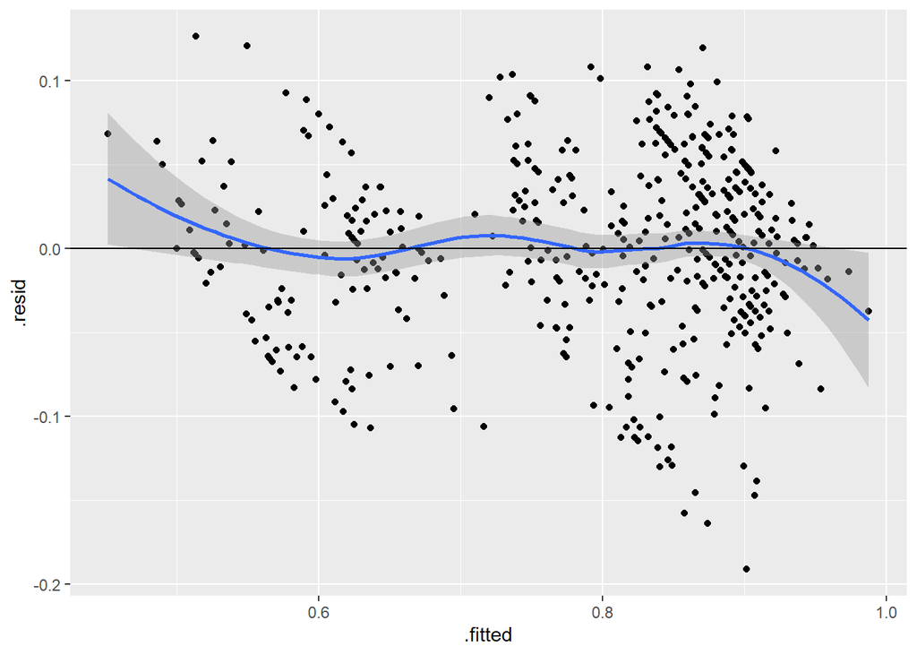

```r
library(ggplot2)
ggplot(interaction_step$model, aes(x=.fitted, y=.resid)) +
geom_point() +
geom_smooth() +
geom_hline(yintercept=0)
```

# There doesn’t seem to be any obvious pattern in the residuals plot, but the data does seem to have a curve for both low and high fitted values. We will check a pairs plot in case certain predictors seem to have higher-order relations.

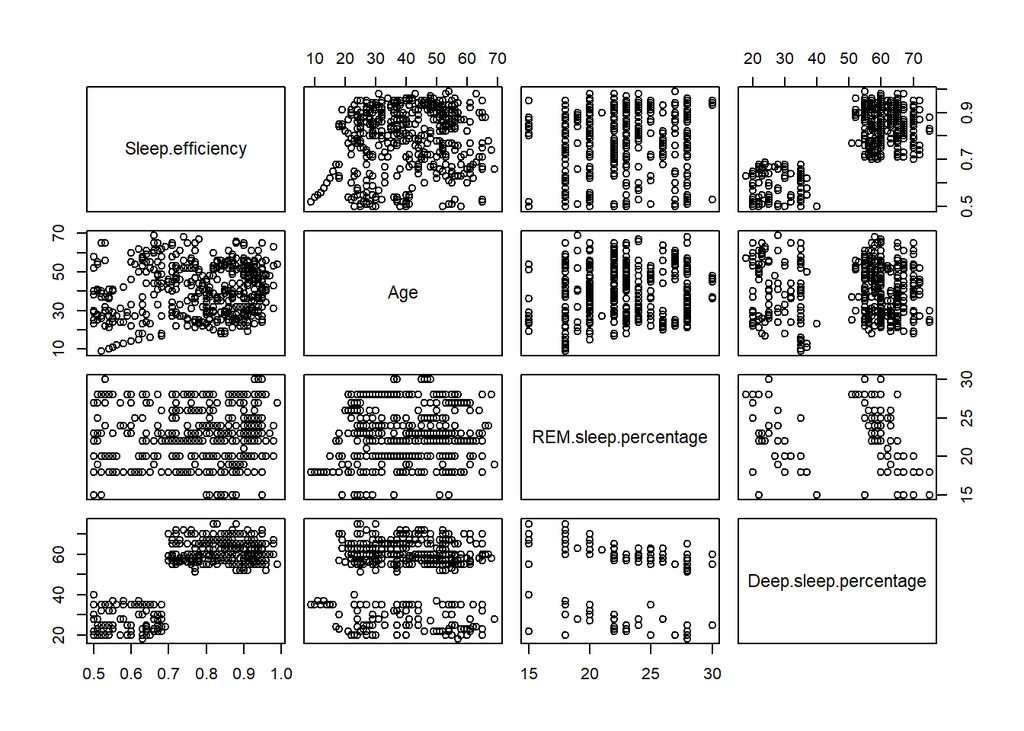

```r
pairs(~Sleep.efficiency+Age+REM.sleep.percentage+Deep.sleep.percentage, data=sleep_data)
```

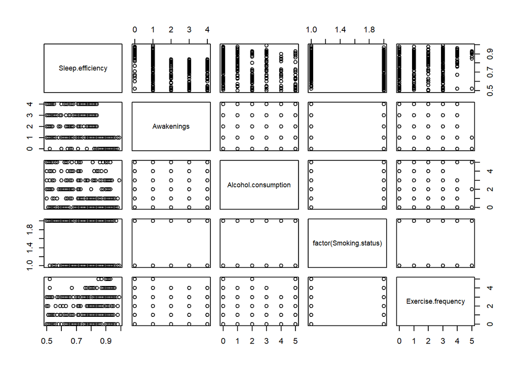

```r
pairs(~Sleep.efficiency+Awakenings+Alcohol.consumption+factor(Smoking.status)+Exercise.frequency, data=sleep_data)
```